# Module Seven Activity

For the module seven activity, you will identify relevant data and write Python code to generate visualizations and interpret insights from the provided data set. Professionals in data-driven fields must not only interpret data but also gather, analyze, and present it in meaningful and actionable ways. This activity allows you to practice these essential skills by working through the complete exploratory data analysis (EDA) process.

*Note:* there are two parts to this assignment. Part One is the coding activity. Part Two is the written report.

Once your code is complete, you will download this notebook as an HTML file by clicking **File**, then **Download As**, then **HTML (.html)** from the Jupyter menu bar. Validate that your code, output, and all visualizations (rendered as images using the display() function) are visible in the html file before submission.

*Missing Blocks:* Ensure that you have clicked **Run** for all blocks before downloading as an HTML file or the block may be missing from your submission. **Images** must be called using the *display()* function, for example: **display(Image(filename="output/{image_name}.png"))**

Specifically, you must address the items from the rubric criteria.

### Part One: Python Code

In this part, you will write Python code to analyze the data and generate visualizations that explore trends.

#### Create multiple, distinct visualizations that explore different aspects of the data using Python Libraries.

Include the following:

- Code comments explaining each step of your analysis

### Part Two: Report

In this part, you will write a reflection to explain the insights gained from your analysis and visualizations. *This part is to be completed in a word document, using the output here to answer the topics.*

- Explain the trends, differences, or outliers you observed in the data.
- Describe any disparities or patterns that may be relevant to the nonprofit’s goals.
- Write a summary of what the data suggests about transit usage across neighborhoods.
- Explain how the visualizations support your conclusions.
- Discuss how your findings could inform the nonprofit’s decision-making or strategy.
- Describe the importance of data-driven insights in addressing real-world challenges.

*To Begin:* This Python template program has been broken down into segments as a guide for what steps you should do at a minimum to complete this activity. Look for the **# To Do:** comments. These are placeholders for you to provide Python code segments. Fill out all **# To Do:** code segments to complete this program.  
*Once Complete:* Execute a "Kernel restart and run all" to verify that all your code works as a single unit by clicking **Kernel**, then **Restart & Run All** before downloading as html.

*Hint:* If you need to install additional packages, see one of the earlier modules on how to configure and call a requirements.txt file.

## Import the Required Packages

```python
import pandas as pd
import matplotlib.pyplot as plt
import seaborn as sns
import os
import matplotlib.image as mpimg

import numpy as np

from IPython.display import Image, display # for image rendering in html output

import matplotlib.dates as mdates

from matplotlib.ticker import PercentFormatter

import matplotlib.ticker as ticker
```

# Part One: Python Code

*Reminder:* Ensure that you add code comments explaining each step of your analysis.

## Define the file path for the dataset

```python
data_path = "data/Feb_2025_Complete_Monthly_Ridership.csv"
```

## Loading the dataset

```python
# To Do: Load the dataset

try:
    data_file = pd.read_csv("data/Feb_2025_Complete_Monthly_Ridership.csv")
    print("Dataset has been loaded")

except FileNotFoundError:
    print("Unable to locate file, please try again")
    exit()
```

```
Dataset has been loaded
```

## Create an output folder if it doesn't already exist

```python
output_folder = "output"
os.makedirs(output_folder, exist_ok=True)
```

## Display Dataset Information

```python
print("Dataset Overview:")
# To Do: Print the first 5 rows of the dataset to inspect the data to ensure it loaded correctly

data_file.head()
```

```
Dataset Overview:
```

|  | NTD ID | Legacy NTD ID | Agency | Mode | TOS | 3 Mode | Mode/Type of Service Status | Reporter Type | Organization Type | HQ City | ... | Last Closed Report Year | Last Closed FY End Month | Last Closed FY End Year | Passenger Miles FY | Unlinked Passenger Trips FY | Avg Trip Length FY | Fares FY | Operating Expenses FY | Avg Cost Per Trip FY | Avg Fares Per Trip FY |
| --- | --- | --- | --- | --- | --- | --- | --- | --- | --- | --- | --- | --- | --- | --- | --- | --- | --- | --- | --- | --- | --- |
| 0 | 1 | 0001 | King County | DR | PT | Bus | Active | Full Reporter | City, County or Local Government Unit or Depar... | SEATTLE | ... | 2023.0 | 12.0 | 2023.0 | 6,470,644 | 888,663 | 7.0 | $816,892.00 | $72,095,003.00 | $81.13 | $0.92 |
| 1 | 1 | 0001 | King County | DR | TX | Bus | Active | Full Reporter | City, County or Local Government Unit or Depar... | SEATTLE | ... | 2023.0 | 12.0 | 2023.0 | 1,509,526 | 121,496 | 12.0 | $105,605.00 | $5,658,724.00 | $46.58 | $0.87 |
| 2 | 1 | 0001 | King County | FB | DO | Ferry | Active | Full Reporter | City, County or Local Government Unit or Depar... | SEATTLE | ... | 2023.0 | 12.0 | 2023.0 | 1,479,694 | 399,687 | 4.0 | $1,493,280.00 | $8,625,721.00 | $21.58 | $3.74 |
| 3 | 1 | 0001 | King County | LR | DO | Rail | Inactive | Full Reporter | City, County or Local Government Unit or Depar... | SEATTLE | ... | 2011.0 | 12.0 | 2011.0 | 471,587 | 520,933 | 1.0 | $288,470.00 | $2,281,393.00 | $4.38 | $0.55 |
| 4 | 1 | 0001 | King County | MB | DO | Bus | Active | Full Reporter | City, County or Local Government Unit or Depar... | SEATTLE | ... | 2023.0 | 12.0 | 2023.0 | 244,710,079 | 63,485,248 | 4.0 | $60,386,305.00 | $710,359,423.00 | $11.19 | $0.95 |

5 rows × 27 columns

```python
print("Column Names:")
# To Do: Print all column names

print(data_file.columns)
```

```
Column Names:
Index(['NTD ID', 'Legacy NTD ID', 'Agency', 'Mode', 'TOS', '3 Mode',
       'Mode/Type of Service Status', 'Reporter Type', 'Organization Type',
       'HQ City', 'HQ State', 'UACE CD', 'UZA Name', 'UZA SQ Miles',
       'UZA Population', 'Service Area Population', 'Service Area SQ Miles',
       'Last Closed Report Year', 'Last Closed FY End Month',
       'Last Closed FY End Year', 'Passenger Miles FY',
       'Unlinked Passenger Trips FY', 'Avg Trip Length FY', 'Fares FY',
       'Operating Expenses FY', 'Avg Cost Per Trip FY',
       'Avg Fares Per Trip FY'],
      dtype='object')
```

```python
# To remove any missing values present in the dataset

data_file_cleaned = data_file.dropna()
```

```python
# To Do: Filter the data for the three neighborhoods and a create an explicit copy

# This done in subsequent steps
```

```python
# To Do: Convert numeric columns to proper formats (removing commas and extra spaces)

# Numeric columns: 'NTD ID', 'Legacy NTD ID', 'UACE CD', 'UZA SQ Miles', 'UZA Population',
# 'Service Area Population', 'Service Area SQ Miles', 'Passenger Miles FY', 'Unlinked
# Passenger Trips FY', 'Avg Trip Length FY', 'Fares FY', 'Operating Expenses FY',
# 'Avg Cost Per Trip FY', 'Avg Fares Per Trip FY'

# Date columns: 'Last Closed Report Year', 'Last Closed FY End Month', 'Last Closed FY End Year'

# Non-numeric columns: 'Agency', 'Mode', 'TOS', '3 Mode', 'Mode/Type of Service Status',
# 'Reporter Type', 'Organization Type', 'HQ City, 'HQ State', 'UZA Name'

numeric_columns = ['NTD ID', 'Legacy NTD ID', 'UACE CD', 'UZA SQ Miles', 'UZA Population',
'Service Area Population', 'Service Area SQ Miles', 'Passenger Miles FY', 'Unlinked Passenger Trips FY',
'Avg Trip Length FY', 'Fares FY', 'Operating Expenses FY','Avg Cost Per Trip FY', 'Avg Fares Per Trip FY']

# To remove commas
data_file_cleaned.loc[:,'Passenger Miles FY'] = pd.to_numeric(data_file_cleaned['Passenger Miles FY'].astype(str).str.replace(',', '', regex=True),errors='coerce',)
data_file_cleaned.loc[:,'Unlinked Passenger Trips FY'] = pd.to_numeric(data_file_cleaned['Unlinked Passenger Trips FY'].astype(str).str.replace(',', '', regex=True),errors='coerce',)

# To remove dollar signs
data_file_cleaned.loc[:,'Avg Cost Per Trip FY'] = pd.to_numeric(data_file_cleaned['Avg Cost Per Trip FY'].astype(str).str.replace('[$]', '', regex=True),errors='coerce',)
data_file_cleaned.loc[:,'Avg Fares Per Trip FY'] = pd.to_numeric(data_file_cleaned['Avg Fares Per Trip FY'].astype(str).str.replace('[$]', '', regex=True),errors='coerce',)

# To remove dollar signs and commas
data_file_cleaned.loc[:,'Fares FY'] = pd.to_numeric(data_file_cleaned['Fares FY'].astype(str).str.replace('[$|,]', '', regex=True),errors='coerce',)
data_file_cleaned.loc[:,'Operating Expenses FY'] = pd.to_numeric(data_file_cleaned['Operating Expenses FY'].astype(str).str.replace('[$|,]', '', regex=True),errors='coerce',)

# To convert date information to the proper format
data_file_cleaned.loc[:,'Last Closed Report Year'] = pd.to_datetime(data_file_cleaned['Last Closed Report Year'].astype(int).astype(str), format='%Y')
data_file_cleaned.loc[:,'Last Closed FY End Year'] = pd.to_datetime(data_file_cleaned['Last Closed FY End Year'].astype(int).astype(str), format='%Y')
```

```python
# To rename the column information to clarify the information presented

data_file_cleaned = data_file_cleaned.rename(
columns = {'Agency': 'Location',
'Mode': 'Transit Type',
'3 Mode': 'Mode Type',
'Mode/Type of Service Status': 'Service Status',
'UZA Name': 'City',
'UZA SQ Miles': 'City Area (Miles)',
'UZA Population': 'City Population',
'Service Area SQ Miles': 'Service Area (Miles)',
'Passenger Miles FY': 'Passenger Miles Travelled',
'Unlinked Passenger Trips FY': 'Total Public Transport Trips',
'Avg Trip Length FY': 'Average Trip Length',
'Fares FY': 'Annual Revenue',
'Operating Expenses': 'Annual Operating Expenses',
'Avg Cost Per Trip FY': 'Average Cost per Trip',
'Avg Fares Per Trip FY': 'Average Fare Charged per Trip',
'Last Closed Report Year': 'Year'})
```

```python
# To drop columns that do not contain information useful for analysis purposes

columns_to_drop = ['NTD ID', 'Legacy NTD ID', 'TOS', 'Reporter Type', 'UACE CD', 'Last Closed FY End Month',
                   'Last Closed FY End Year']

cleaned_data = data_file_cleaned.drop(columns=columns_to_drop)
```

```python
# To filter data to exclude "Inactive" tranportation types

cleaned_data = cleaned_data[cleaned_data['Service Status'].isin(['Active'])]
```

```python
# To rename the relevant Transit Type values to convert them from their
# abbreviation to full name, names were obtained from:
# https://www.transit.dot.gov/ntd/national-transit-database-ntd-glossary#D

transit_type_names= {
'DR': 'Demand Response',
'FB': 'Ferryboat',
'LR': 'Light Rail',
'MB': 'Bus',
'SR': 'Streetcar Rail',
'TB': 'Trolleybus',
'VP': 'Vanpool',
'CB': 'Commuter Bus'}

cleaned_data['Transit Type'] = cleaned_data['Transit Type'].map(transit_type_names)

cleaned_data.info()
```

```
<class 'pandas.core.frame.DataFrame'>
Index: 1228 entries, 0 to 2299
Data columns (total 20 columns):
 #   Column                         Non-Null Count  Dtype
---  ------                         --------------  -----
 0   Location                       1228 non-null   object
 1   Transit Type                   1148 non-null   object
 2   Mode Type                      1228 non-null   object
 3   Service Status                 1228 non-null   object
 4   Organization Type              1228 non-null   object
 5   HQ City                        1228 non-null   object
 6   HQ State                       1228 non-null   object
 7   City                           1228 non-null   object
 8   City Area (Miles)              1228 non-null   float64
 9   City Population                1228 non-null   float64
 10  Service Area Population        1228 non-null   float64
 11  Service Area (Miles)           1228 non-null   float64
 12  Year                           1228 non-null   datetime64[ns]
 13  Passenger Miles Travelled      1228 non-null   object
 14  Total Public Transport Trips   1228 non-null   object
 15  Average Trip Length            1228 non-null   float64
 16  Annual Revenue                 1228 non-null   object
 17  Operating Expenses FY          1228 non-null   object
 18  Average Cost per Trip          1228 non-null   object
 19  Average Fare Charged per Trip  1228 non-null   object
dtypes: datetime64[ns](1), float64(5), object(14)
memory usage: 201.5+ KB
```

```python
cleaned_data.describe()
```

|  | City Area (Miles) | City Population | Service Area Population | Service Area (Miles) | Year | Average Trip Length |
| --- | --- | --- | --- | --- | --- | --- |
| count | 1228.000000 | 1.228000e+03 | 1.228000e+03 | 1228.000000 | 1228 | 1228.000000 |
| mean | 652.828355 | 2.674108e+06 | 1.091152e+06 | 709.828990 | 2022-11-19 11:16:36.742670848 | 10.375407 |
| min | 0.000000 | 5.072000e+04 | 1.299700e+04 | 3.000000 | 2008-01-01 00:00:00 | 0.000000 |
| 25% | 92.805000 | 2.244490e+05 | 1.683958e+05 | 82.750000 | 2023-01-01 00:00:00 | 4.000000 |
| 50% | 300.530000 | 7.698370e+05 | 3.990070e+05 | 288.000000 | 2023-01-01 00:00:00 | 6.000000 |
| 75% | 910.370000 | 3.070300e+06 | 1.102307e+06 | 675.000000 | 2023-01-01 00:00:00 | 10.000000 |
| max | 3248.120000 | 1.942645e+07 | 1.163811e+07 | 15355.000000 | 2023-01-01 00:00:00 | 124.000000 |
| std | 802.200002 | 4.450843e+06 | 1.853463e+06 | 1348.322216 | NaN | 12.344945 |

```python
# To add a column to the dataset to classify the information based on the size of the
# population into city classification groups

conditions = [cleaned_data['City Population'] <= 200000,
    (cleaned_data['City Population'] > 200000) & (cleaned_data['City Population'] <= 500000),
    (cleaned_data['City Population'] > 500000) & (cleaned_data['City Population'] <= 1500000),
    cleaned_data['City Population'] > 1500000,]

choices = ['Small Urban Area','Medium-Size Urban Area',
    'Metropolitan Area','Large Metropolitan Area',]

cleaned_data['Location Type'] = np.select(conditions, choices, default='Other')
```

## Generate, Save, and Output Visualizations

*Example Visualizations:* The three visualization placeholders below are example visualization placeholders for the data using a provided template. These are simple example frameworks that you may use, but you may, and are encouraged to develop your own visualizations that you will then explain how the selected visualizations support your conclusions in the part two report.

### Visualization 1: Line chart of ridership trends over years

This is an example visualization you can generate. You may implement a chart and assessment of your choosing in lieu of this placeholder.

#### At a minimum include the following actions:

- Add title and axis labels
- Save the plot to a png file in the 'output' folder
- Use the display() function to render the generated png image in the html output
- Comments explaining each step of your analysis

```python
# To Do: Create a visualization that will support your conclusions for part two
```

```python
# Note the following graphs will be combined into one figure in the report
# to provide the nonprofit organizations will relevant information about trends
# in public transportation at a national, regional, and local level
```

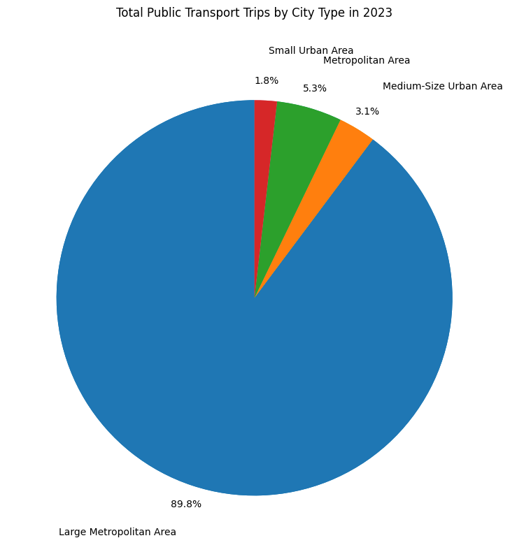

```python
# To create National figure showing the breakdown of Total Public Transport Trips
# per Location Type (Small Urban Area, Medium-Size Urban Area, Metropolitan Area,
# and Large Metropolitan Area)

visual_1df = cleaned_data.copy()

# To filter the data for 2023

visual_1df['Year'] = pd.to_datetime(visual_1df['Year'], format='%Y')
visual_1df_2023 = visual_1df[visual_1df['Year'].dt.year == 2023]

# Color-blind friendly colors

colors= ["#0072B2", "#E69F00", "#009E73", "#CC79A7"]

# Location for file output

output_dir = "output"
os.makedirs(output_dir, exist_ok=True)
output_path = os.path.join(output_dir, "pie_chart_national.png")

# Create the pie chart

plt.figure(figsize=(8, 8))

location_type =visual_1df_2023.groupby('Location Type')['Total Public Transport Trips'].sum()
location_type.plot(kind='pie', autopct='%1.1f%%', startangle=90, colors=colors,pctdistance=1.10,labeldistance=1.25)

# Add labels and title

plt.title('Total Public Transport Trips by City Type in 2023', pad=35)
plt.ylabel('')

plt.pie(location_type, labels=None, autopct=None, startangle=90)

plt.tight_layout()
plt.savefig(output_path, bbox_inches="tight", dpi=100)
plt.close()

# Use the display() function to render the generated png image in the html output
display(Image(filename="output/pie_chart_national.png"))
```

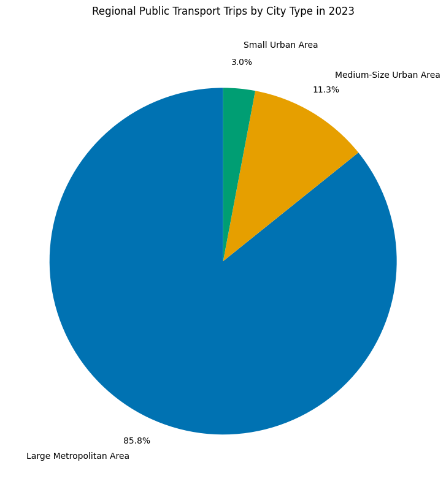

```python
# To create Regional (WA and OR) figure showing the breakdown of Total Public Transport Trips
# per Location Type (Small Urban Area, Medium-Size Urban Area, Metropolitan Area,
# and Large Metropolitan Area)

visual_2df = cleaned_data.copy()

# To filer the data for WA and OR

visual_2df = visual_2df[visual_2df['HQ State'].isin(['WA', 'OR'])]

# To filter the data for 2023

visual_2df['Year'] = pd.to_datetime(visual_2df['Year'], format='%Y')
visual_2df_2023 = visual_2df[visual_2df['Year'].dt.year == 2023]

# Color-blind friendly colors

colors= ["#0072B2", "#E69F00", "#009E73", "#CC79A7"]

# Location for file output

output_dir = "output"
os.makedirs(output_dir, exist_ok=True)
output_path = os.path.join(output_dir, "pie_chart_regional.png")

# Create the pie chart

plt.figure(figsize=(8, 8))

location_type =visual_2df_2023.groupby('Location Type')['Total Public Transport Trips'].sum()
location_type.plot(kind='pie', autopct='%1.1f%%', startangle=90, colors=colors,pctdistance=1.15,labeldistance=1.25)

# Add labels and title

plt.title('Regional Public Transport Trips by City Type in 2023', pad=35)
plt.ylabel('')

# Save the plot to a png file in the 'output'folder

plt.tight_layout()
plt.savefig(output_path, bbox_inches="tight", dpi=100)
plt.close()

# Use the display() function to render the generated png image in the html output
display(Image(filename="output/pie_chart_regional.png"))
```

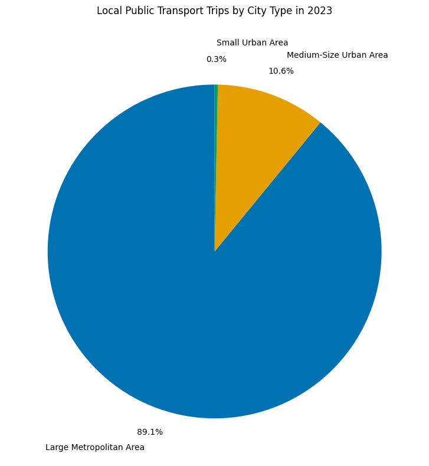

```python
# To create Local (the three neighborhoods) figure showing the breakdown of Total Public Transport Trips
# per Location Type (Small Urban Area, Medium-Size Urban Area, Metropolitan Area,
# and Large Metropolitan Area)

visual_3df = cleaned_data.copy()

# To filter the data to include the relevant neighbhorhoods

visual_3df = visual_3df[visual_3df['Location'].isin(["King County", "City of Longview", "Spokane Transit Authority"])]

# To filter the data for 2023

visual_3df['Year'] = pd.to_datetime(visual_3df['Year'], format='%Y')
visual_3df_2023 = visual_3df[visual_3df['Year'].dt.year == 2023]

# Color-blind friendly colors

colors= ["#0072B2", "#E69F00", "#009E73", "#CC79A7"]

# Location for file output

output_dir = "output"
os.makedirs(output_dir, exist_ok=True)
output_path = os.path.join(output_dir, "pie_chart_local.png")

# Create the pie chart

plt.figure(figsize=(8, 8))

location_type =visual_3df_2023.groupby('Location Type')['Total Public Transport Trips'].sum()
location_type.plot(kind='pie', autopct='%1.1f%%', startangle=90, colors=colors,pctdistance=1.15,labeldistance=1.25)

# Add labels and title

plt.title('Local Public Transport Trips by City Type in 2023', pad=35)
plt.ylabel('')

# Save the plot to a png file in the 'output'folder

plt.tight_layout()
plt.savefig(output_path, bbox_inches="tight", dpi=100)
plt.close()

# Use the display() function to render the generated png image in the html output
display(Image(filename="output/pie_chart_local.png"))
```

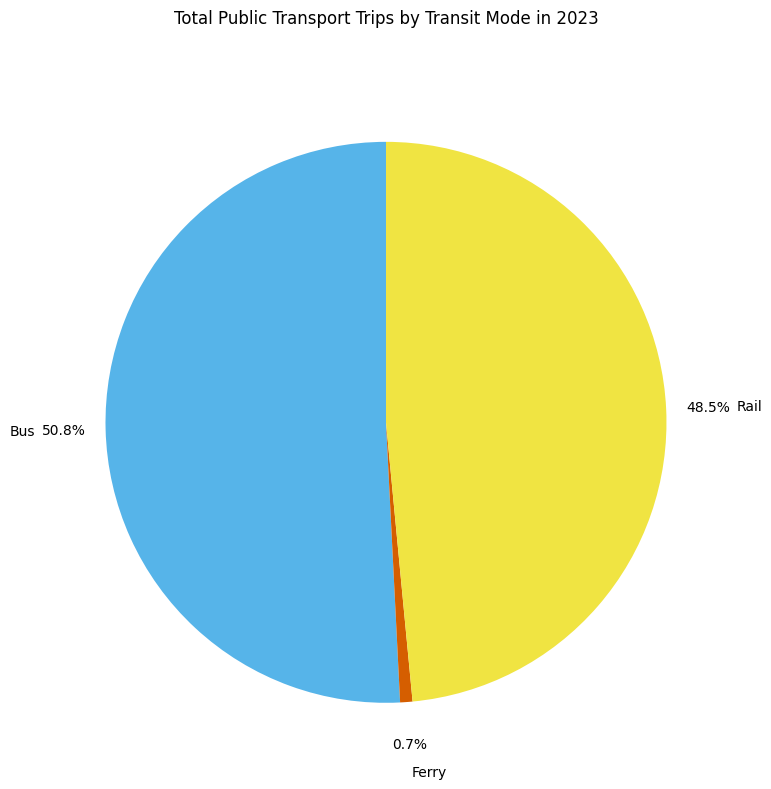

```python
# To create National figure showing the breakdown of Total Public Transport Trips
# by Mode Type (bus, rail, or ferry)

visual_4df = cleaned_data.copy()

# To filter the data for 2023

visual_4df['Year'] = pd.to_datetime(visual_4df['Year'], format='%Y')
visual_4df_2023 = visual_4df[visual_1df['Year'].dt.year == 2023]

# Color-blind friendly colors

colors= ["#56B4E9", "#D55E00", "#F0E442"]

# Location for file output

output_dir = "output"
os.makedirs(output_dir, exist_ok=True)
output_path = os.path.join(output_dir, "pie_chart_national_mode.png")

# Create the pie chart

plt.figure(figsize=(8, 8))

location_type = visual_4df_2023.groupby('Mode Type')['Total Public Transport Trips'].sum()
location_type.plot(kind='pie', autopct='%1.1f%%', startangle=90, colors=colors,pctdistance=1.15,labeldistance=1.25)

# Add labels and title

plt.title('Total Public Transport Trips by Transit Mode in 2023', pad=35)
plt.ylabel('')

# Save the plot to a png file in the 'output'folder

plt.tight_layout()
plt.savefig(output_path, bbox_inches="tight", dpi=100)
plt.close()

# Use the display() function to render the generated png image in the html output
display(Image(filename="output/pie_chart_national_mode.png"))
```

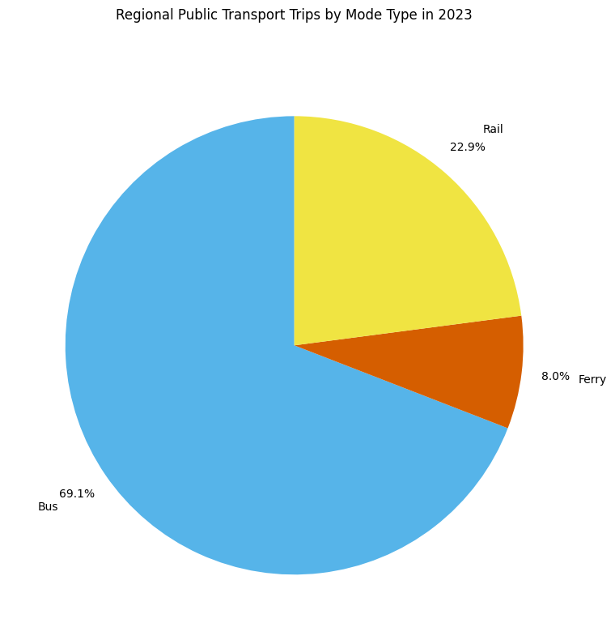

```python
# To create Regional (WA and OR) figure showing the breakdown of Total Public Transport Trips
# by Mode Type (bus, rail, or ferry)

visual_5df = cleaned_data.copy()

# To filter the data for WA and OR

visual_5df = visual_5df[visual_5df['HQ State'].isin(['WA', 'OR'])]

# To filter the data for 2023

visual_5df['Year'] = pd.to_datetime(visual_5df['Year'], format='%Y')
visual_5df_2023 = visual_5df[visual_5df['Year'].dt.year == 2023]

# Color-blind friendly colors

colors= ["#56B4E9", "#D55E00", "#F0E442"]

# Location for file output

output_dir = "output"
os.makedirs(output_dir, exist_ok=True)
output_path = os.path.join(output_dir, "pie_chart_regional_mode.png")

# Create the pie chart

plt.figure(figsize=(8, 8))

location_type =visual_5df_2023.groupby('Mode Type')['Total Public Transport Trips'].sum()
location_type.plot(kind='pie', autopct='%1.1f%%', startangle=90, colors=colors,pctdistance=1.15,labeldistance=1.25)

# Add labels and title

plt.title('Regional Public Transport Trips by Mode Type in 2023', pad=35)
plt.ylabel('')

# Save the plot to a png file in the 'output'folder

plt.tight_layout()
plt.savefig(output_path, bbox_inches="tight", dpi=100)
plt.close()

# Use the display() function to render the generated png image in the html output
display(Image(filename="output/pie_chart_regional_mode.png"))
```

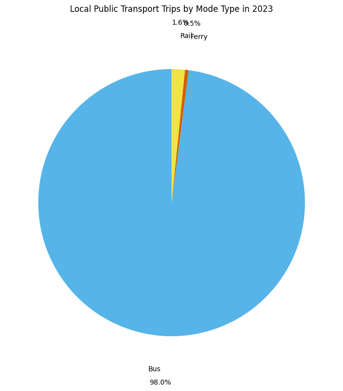

```python
# To create Local (the three neighborhoods) figure showing the breakdown of Total Public Transport Trips
# by Mode Type (bus, rail, or ferry)

visual_6df = cleaned_data.copy()

# To filter the data to include the relevant neighbhorhoods

visual_6df = visual_6df[visual_6df['Location'].isin(["King County", "City of Longview", "Spokane Transit Authority"])]

# To filter the data for 2023

visual_6df['Year'] = pd.to_datetime(visual_6df['Year'], format='%Y')
visual_6df_2023 = visual_6df[visual_6df['Year'].dt.year == 2023]

# Color-blind friendly colors

colors= ["#56B4E9", "#D55E00", "#F0E442"]

# Location for file output

output_dir = "output"
os.makedirs(output_dir, exist_ok=True)
output_path = os.path.join(output_dir, "pie_chart_local_mode.png")

# Create the pie chart

plt.figure(figsize=(8, 8))

location_type =visual_6df_2023.groupby('Mode Type')['Total Public Transport Trips'].sum()
location_type.plot(kind='pie', autopct='%1.1f%%', startangle=90, colors=colors,pctdistance=1.35,labeldistance=1.25)

# Add labels and title

plt.title('Local Public Transport Trips by Mode Type in 2023', pad=35)
plt.ylabel('')

# Save the plot to a png file in the 'output'folder

plt.tight_layout()
plt.savefig(output_path, bbox_inches="tight", dpi=100)
plt.close()

# Use the display() function to render the generated png image in the html output
display(Image(filename="output/pie_chart_local_mode.png"))
```

```python
# Please see the final report for the incorporation of the information
# from the three graphs into a single figure
```

### Visualization 2: Bar chart comparing total ridership across neighborhoods

This is an example visualization you can generate. You may implement a chart and assessment of your choosing in lieu of this placeholder.

#### At a minimum include the following actions:

- Add title and axis labels
- Save the plot to a png file in the 'output' folder
- Use the display() function to render the generated png image in the html output
- Comments explaining each step of your analysis

```python
# To Do: Create a visualization that will support your conclusions for part two
```

```python
# Note: the purpose of this figure is to provide comparison information
# regarding each of the three neighborhoods and the relevant comparison
# neighborhoods. The comparison neighborhoods were chosen based on being
# located in WA or OR and having a population size similar that of one of
# three neighbhorhoods being analyszed

# Below is the neighhorhood along with the comparison neighorhood:
# 1) King County -> Tri-County Metropolitan Transportation District of Oregon
# 2) Spokane Transit Authority -> Lane Transit District
# 3) City of Longview -> Skagit Transit
```

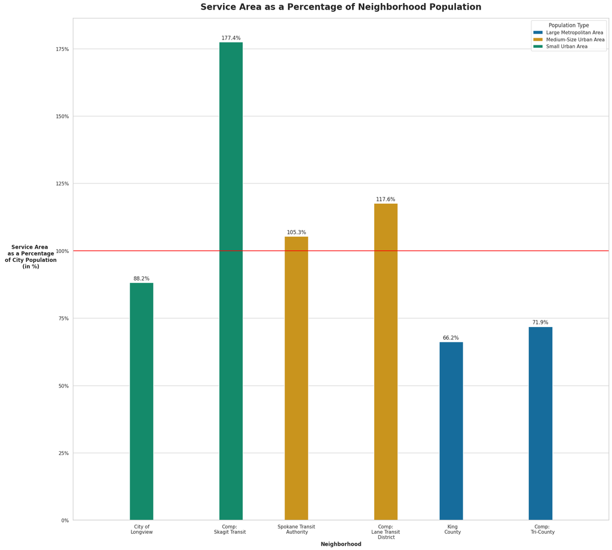

```python
# To create a grouped bar chart comparing the service area population to the
# total city/neighbhorhood population. This will allow a comparison to be made
# between each neighborhood as well as between each individul neighbhorhood
# and it's comparison neighbhorhood

visual_7df = cleaned_data.copy()

# To filter the data to include the relevant neighbhorhoods

visual_7df = visual_7df[visual_7df['Location'].isin(["King County", "City of Longview",
"Spokane Transit Authority","Skagit Transit", "Tri-County Metropolitan Transportation District of Oregon",
"Lane Transit District"])]

# To filter the data for 2023

visual_7df['Year'] = pd.to_datetime(visual_7df['Year'], format='%Y')
visual_7df_2023 = visual_7df[visual_7df['Year'].dt.year == 2023]

# To calculate the Service Area Population as a Percentage of the City Population
# for the relevant neighbhorhoods and their comparison neighbhorhoods

visual_7df['Service Area %'] = visual_7df['Service Area Population'] / visual_7df['City Population']

visual_7df = visual_7df.sort_values(by='Location Type')

# Color-blind friendly colors

colors= ["#0072B2", "#E69F00", "#009E73"]

# Location for file output

output_dir = "output"
os.makedirs(output_dir, exist_ok=True)
output_path = os.path.join(output_dir, "comparison_bar_chart.png")

# Creating order of bar chart columns

bar_chart_order = ['City of Longview', 'Skagit Transit', 'Spokane Transit Authority', 'Lane Transit District',
                  'King County', 'Tri-County Metropolitan Transportation District of Oregon']

# Create the bar chart

sns.set_theme(style='whitegrid')
plt.figure(figsize=(20, 18))
ax = sns.barplot(
    data=visual_7df,
    x='Location',
    y='Service Area %',
    hue='Location Type',
    palette=colors,
    dodge=True,
    order=bar_chart_order,
)

# Add labels and title

plt.title('Service Area as a Percentage of Neighborhood Population',fontweight='bold', pad=20, fontsize=20)
plt.xlabel('Neighborhood')
plt.ylabel('Service Area as a % of City Population', labelpad=60)
plt.legend(title='Population Type')

for container in ax.containers:
  ax.bar_label(container, padding=3, fmt='{:.1%}')

ax.axhline(y=1.00, color='red')

ax.yaxis.set_major_formatter(PercentFormatter(xmax=1.0))

ax.set_ylabel("Service Area\n as a Percentage\n of City Population\n (in %)", rotation=0, fontweight='bold')
ax.set_xlabel("Neighborhood", rotation=0, fontweight='bold')

plt.xticks(ticks=[0.27, 1.25, 2, 3, 3.75, 4.75], labels=["City of\nLongview", "Comp:\n Skagit Transit", "Spokane Transit\n Authority",
"Comp:\nLane Transit\n District", "King\nCounty", "Comp:\n Tri-County"], rotation=0, ha ='center')

# Save the plot to a png file in the 'output'folder

plt.tight_layout()
plt.savefig(output_path, bbox_inches="tight", dpi=100)
plt.close()

# Use the display() function to render the generated png image in the html output

display(Image(filename="output/comparison_bar_chart.png"))
```

### Visualization 3: Scatterplot of ridership vs population

This is an example visualization you can generate. You may implement a chart and assessment of your choosing in lieu of this placeholder.

#### At a minimum include the following actions:

- Add title and axis labels
- Save the plot to a png file in the 'output' folder
- Use the display() function to render the generated png image in the html output
- Comments explaining each step of your analysis

```python
# To Do: Create a visualization that will support your conclusions for part two
```

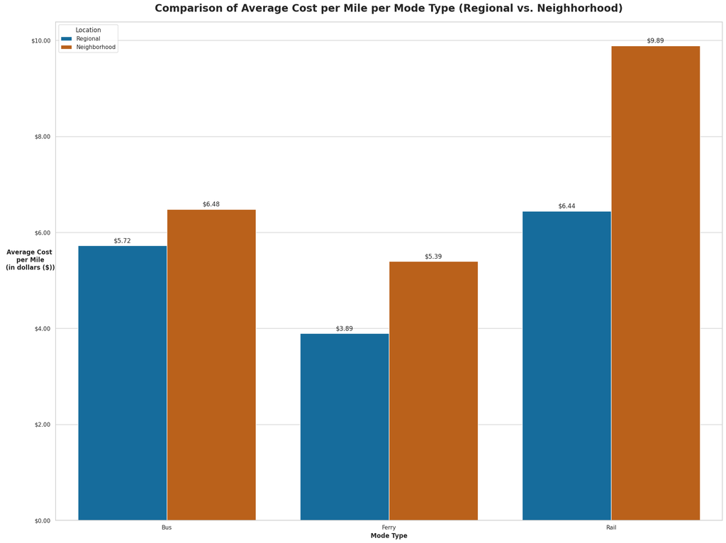

```python
# Note: the purpose of this figure is to examine the operating expenses of the
# three neighbhorhoods part of this analysis. The analysis should account for
# longer trips,in terms of miles, having higher operating expenses. Therefore the
# Average Trip Length column will be used to calculate the average cost per mile
# on the given public transportation. This figure will compare the regional average
# with the local, or neighbhorhood, average cost per mile

visual_8df = cleaned_data.copy()

# To filter the data for WA and OR

visual_8df = visual_8df[visual_8df['HQ State'].isin(['WA', 'OR'])]

# To filter the data for 2023

visual_8df['Year'] = pd.to_datetime(visual_8df['Year'], format='%Y')
visual_8df_2023 = visual_8df[visual_8df['Year'].dt.year == 2023]

# To calculate the average cost per mile on each type of public transportation

visual_8df['Cost per Mile'] = visual_8df['Average Cost per Trip'].values / visual_8df['Average Trip Length'].values

# To find the average Cost per Mile for each Mode Type in WA and OR

visual_8df_pivoted_regional = visual_8df.groupby(['Mode Type'])['Cost per Mile'].mean().reset_index()

visual_8df_pivoted_regional['Location'] = 'Regional'

# To find the average Cost per Mile for each of the three neighborhoods

visual_8df_pivoted_neighborhood = visual_8df.groupby(['Mode Type', 'Location'])['Cost per Mile'].mean().reset_index()

visual_8df_pivoted_neighborhood = visual_8df_pivoted_neighborhood[visual_8df_pivoted_neighborhood['Location'].isin(["King County",
"City of Longview","Spokane Transit Authority"])]

visual_8df_pivoted_neighborhood_average = (visual_8df_pivoted_neighborhood.groupby("Mode Type")["Cost per Mile"].mean().reset_index())

visual_8df_pivoted_neighborhood_average ['Location'] = 'Neighborhood'

# Combining regional and neighborhood averages into one dataset

combined_df = pd.concat([visual_8df_pivoted_regional, visual_8df_pivoted_neighborhood_average], ignore_index=True)

# Color-blind friendly colors

colors= ["#0072B2", "#D55E00"]

# Location for file output

output_dir = "output"
os.makedirs(output_dir, exist_ok=True)
output_path = os.path.join(output_dir, "regional_cost_per_mile_bar_chart.png")

# Create the bar chart

sns.set_theme(style='whitegrid')
plt.figure(figsize=(20, 15))
ax = sns.barplot(data=combined_df, x='Mode Type', y='Cost per Mile', hue='Location', palette=colors, dodge=True)

for container in ax.containers:
  ax.bar_label(container, padding=3, fmt='${:,.2f}')

# Add labels and title

plt.title('Comparison of Average Cost per Mile per Mode Type (Regional vs. Neighhorhood)', fontweight='bold', pad=20, fontsize=20)
plt.xlabel("Mode Type", fontweight='bold')
plt.ylabel("Average Cost\n per Mile\n (in dollars ($))", fontweight="bold", rotation=0)

plt.gca().yaxis.set_major_formatter(ticker.StrMethodFormatter('${x:,.2f}'))

# Save the plot to a png file in the 'output'folder

plt.tight_layout()
plt.savefig(output_path, bbox_inches="tight", dpi=100)
plt.close()

# Use the display() function to render the generated png image in the html output

display(Image(filename="output/regional_cost_per_mile_bar_chart.png"))
```

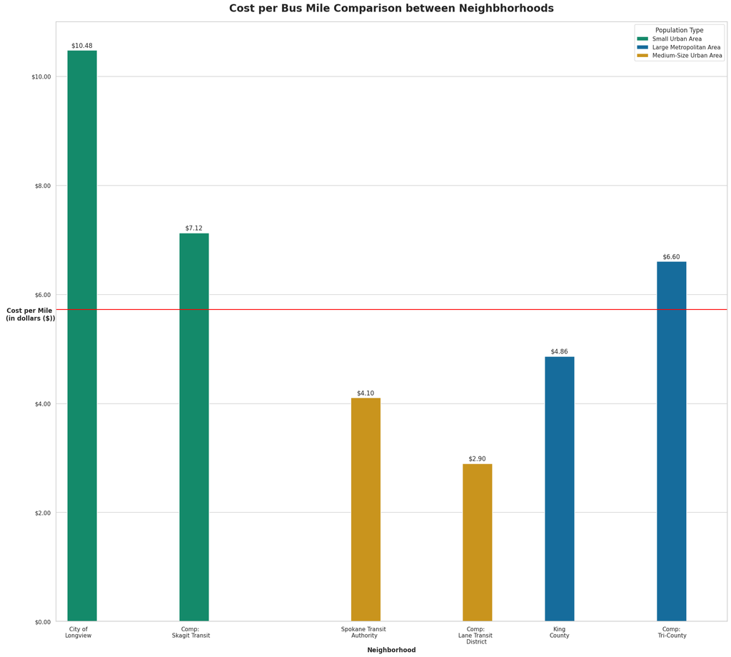

```python
# Note: the purpose of this figure is to examine the operating expenses of the
# three neighbhorhoods in the this analysis. The analysis should account for
# longer trips,in terms of miles, having higher operating expenses. Therefore the
# Average Trip Length column will be used to calculate the average cost per mile
# on the given public transportation This figure will compare each of the three
# neighbhorhoods with their assigned comparison neighborhood

# To compare neighborhood date with comparison neighorhood (buses only)

visual_9df = cleaned_data.copy()

# To filter the data for the relevant neighborhoods

visual_9df = visual_9df[visual_9df['Location'].isin(["King County", "City of Longview",
"Spokane Transit Authority","Skagit Transit", "Tri-County Metropolitan Transportation District of Oregon",
"Lane Transit District"])]

# To filter the data for 2023

visual_9df['Year'] = pd.to_datetime(visual_9df['Year'], format='%Y')
visual_9df_2023 = visual_9df[visual_9df['Year'].dt.year == 2023]

# To calculate the average cost per mile on each type of public transportation

visual_9df['Cost per Mile'] = visual_9df['Average Cost per Trip'].values / visual_9df['Average Trip Length'].values

# To filter for bus information only

visual_9df = visual_9df[visual_9df['Mode Type'].isin(["Bus"])]

# To find the average Cost per Mile for each the Bus Mode Type for the relevant
# neighborhoods

visual_9df_pivoted_neighbhorhood = visual_9df.groupby(['Location','Location Type'])['Cost per Mile'].mean().reset_index()

# Color-blind friendly colors

colors= ["#009E73","#0072B2","#E69F00"]

# Location for file output

output_dir = "output"
os.makedirs(output_dir, exist_ok=True)
output_path = os.path.join(output_dir, "neighbhorhood_cost_per_mile_bar_chart.png")

# Creating order of bar chart columns

bar_chart_order = ['City of Longview', 'Skagit Transit', 'Spokane Transit Authority', 'Lane Transit District',
                  'King County', 'Tri-County Metropolitan Transportation District of Oregon']

# Create the bar chart

sns.set_theme(style='whitegrid')
plt.figure(figsize=(20, 18))
ax = sns.barplot(
    data=visual_9df_pivoted_neighbhorhood,
    x='Location',
    y='Cost per Mile',
    hue='Location Type',
    palette=colors,
    dodge=True,
    order=bar_chart_order,
)

for container in ax.containers:
  ax.bar_label(container, padding=3, fmt='${:,.2f}')

ax.axhline(y=5.72, color='red')

# Add labels and title

plt.title('Cost per Bus Mile Comparison between Neighbhorhoods', fontweight='bold', pad=20, fontsize=20)
plt.xlabel('Neighborhood')
plt.ylabel('Cost per Mile')
plt.legend(title='Population Type')

ax.yaxis.set_major_formatter(ticker.StrMethodFormatter("${x:,.2f}"))

ax.set_ylabel("Cost per Mile\n (in dollars ($))", rotation=0, fontweight='bold')
ax.set_xlabel("Neighborhood", rotation=0, fontweight='bold')

plt.xticks(ticks=[-0.30, 0.70, 2.25, 3.25, 4, 5], labels=["City of\nLongview", "Comp:\n Skagit Transit", "Spokane Transit\n Authority",
"Comp:\nLane Transit\n District", "King\nCounty", "Comp:\n Tri-County"], rotation=0, ha ='center')

# Save the plot to a png file in the 'output'folder

plt.tight_layout()
plt.savefig(output_path, bbox_inches="tight", dpi=100)
plt.close()

# Use the display() function to render the generated png image in the html output

display(Image(filename="output/neighbhorhood_cost_per_mile_bar_chart.png"))
```

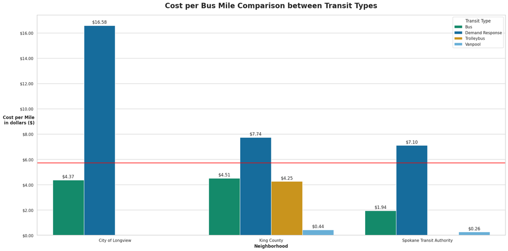

```python
# Note: the purpose of this figure is to breakdown the bus average
# cost per mile by specific transit type to try and determine which
# types are causing these higher costs in comparison with the other
# three similar neighbhorhoods

visual_10df = cleaned_data.copy()

# To filter the data for the relevant neighborhoods

visual_10df = visual_10df[visual_10df['Location'].isin(["King County", "City of Longview",
"Spokane Transit Authority"])]

# To filter the data for 2023

visual_10df['Year'] = pd.to_datetime(visual_10df['Year'], format='%Y')
visual_10df_2023 = visual_10df[visual_10df['Year'].dt.year == 2023]

# To calculate the average cost per mile on each type of public transportation

visual_10df['Cost per Mile'] = visual_10df['Average Cost per Trip'].values / visual_10df['Average Trip Length'].values

# To filter for bus information only

visual_10df = visual_10df[visual_10df['Mode Type'].isin(["Bus"])]

# To find the average Cost per Mile for each the Bus Mode Type for the relevant
# neighborhoods

visual_10df_pivoted_neighbhorhood = visual_10df.groupby(['Location','Transit Type'])['Cost per Mile'].mean().reset_index()

# Color-blind friendly colors

colors= ["#009E73","#0072B2","#E69F00","#56B4E9"]

# Location for file output

output_dir = "output"
os.makedirs(output_dir, exist_ok=True)
output_path = os.path.join(output_dir, "transit_type_cost_per_mile_bar_chart.png")

# Create the bar chart

sns.set_theme(style='whitegrid')
plt.figure(figsize=(20, 10))
ax = sns.barplot(
    data=visual_10df_pivoted_neighbhorhood,
    x='Location',
    y='Cost per Mile',
    hue='Transit Type',
    palette=colors,
    dodge=True,
)

for container in ax.containers:
  ax.bar_label(container, padding=3, fmt='${:,.2f}')

ax.axhline(y=5.72, color='red')

# Add labels and title
plt.title('Cost per Bus Mile Comparison between Transit Types', fontweight='bold', pad=20, fontsize=20)
plt.xlabel('Neighborhood')
plt.ylabel('Cost per Mile')
plt.legend(title='Transit Type', loc='upper right')

ax.yaxis.set_major_formatter(ticker.StrMethodFormatter("${x:,.2f}"))

ax.set_ylabel("Cost per Mile\n in dollars ($)", rotation=0, fontweight='bold')
ax.set_xlabel("Neighborhood", rotation=0, fontweight='bold')


# Save the plot to a png file in the 'output'folder
plt.tight_layout()
plt.savefig(output_path, bbox_inches="tight", dpi=100)
plt.close()

# Use the display() function to render the generated png image in the html output
display(Image(filename="output/transit_type_cost_per_mile_bar_chart.png"))
```